# International Severe Acute Respiratory and Emerging Infections Consortium (ISARIC)

*A global federation of clinical research networks, providing a proficient, coordinated, and agile research response to outbreak-prone infectious diseases*

# COVID-19 Report: 02 April 2020

# 1 Summary

The results in this report have been produced using data from the ISARIC COVID-19 database. For information, or to contribute to the collaboration, please contact ncov@isaric.org

We thank all of the data contributors for collecting standardised data during these extraordinary times. We plan to issue this report of aggregate data weekly for the duration of the SARS-CoV-2/COVID-19 pandemic.

Please note the following caveats. Information is incomplete for the many patients who are still being treated. Note that we received more cases of severely ill individuals than people with relatively less severe illness; outcomes from these data, such as the proportion dying, must therefore not be used to infer outcomes for the entire population of people who might become infected. Many of the included cases are from the United Kingdom. Additional caveats are provided in the in the ‘Caveats’ section below.

The analysis detailed in this report only includes individuals for whom data collection commenced on or before 19 March 2020. We have applied a 14-day rule to focus analysis on individuals who are more likely to have a recorded outcome. By excluding patients enrolled during the last 14 days, we aim to reduce the number of incomplete data records and thus improve the generalisability of the results and the accuracy of the outcomes. However, this limits our analysis to this restricted cohort despite the much larger volumes of data held in the database.

The cohort comprises **1123** individuals, including 621 males and 413 females – sex is unreported for 89 cases.

The median age (calculated based on reported age) is 68 years. The minimum and maximum observed ages are 0 and 97 years respectively.

Outcomes have been recorded for 519 patients, consisting of 346 recoveries and 173 deaths. Follow-up is ongoing for 571 patients.

The observed mean duration for the number of days from hospital admission to outcome (death or discharge) is 6.5 days, with a standard deviation (SD) of 5.7. These estimates are based on all cases which have complete records on length of hospital stay (N = 550).

The observed mean number of days from (first) symptom onset to hospital admission is 6.9 (SD: 5.9).

The symptoms on admission represent the policy for hospital admission and containment at that time plus, whatever the case definition was. As time passes for most countries these will change. The four most common symptoms at admission were fatigue and malaise alongside cough, history of fever and shortness of breath.

251 patients were admitted at some point of their illness into intensive care unit (ICU). The observed mean duration (in days) from hospital admission to ICU is 2.9 (SD: 4.5) – estimated from records on cases with complete date records on hospital admission and ICU entry (N = 177).

The duration of stay in the ICU has a mean of 6.9 days (SD: 4.7 days) – estimated on only those cases with complete records for ICU duration or ICU start/end dates (N = 67). Of these 251 patients who were admitted into ICU, 51 died, 157 are still in hospital and 26 have recovered and been discharged.

107 patients received non-invasive mechanical ventilation (NIV). The mean duration from admission to receiving NIV is 4 days (SD: 7 days) – estimated from records on cases with complete records on dates of hospital admission and NIV onset (N = 96).

The mean duration for NIV is 1.3 days (SD: 1.6 days) – estimated based on only those cases which have complete NIV duration records (N = 46).

154 patients received invasive mechanical ventilation (IMV). The mean duration from admission to receiving IMV is 2.4 days (SD: 3.3 days) – estimated from records on cases with complete records on dates of hospital admission and IMV onset (N = 148).

The mean and SD for the duration of IMV – estimated based on all 33 cases with complete records on IMV stays – is 8.4 days and 4.9 days respectively.

# 2 Patient Characteristics

**Figure 1**: Age and sex distribution of patients. Bar fills are outcome (death/discharge/ongoing care) at the time of report.

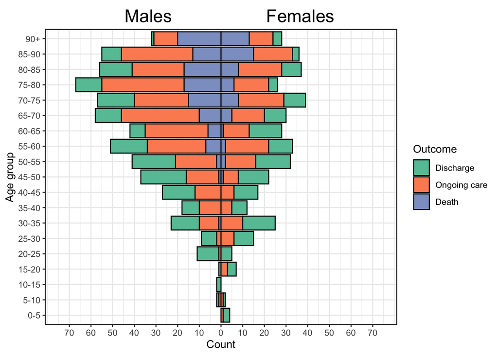

**Figure 2**: Top: Frequency of symptoms seen at admission amongst COVID-19 patients. Bottom: The distribution of combinations of the four most common symptoms, amongst all patients for whom this data was recorded. Filled and empty circles below the x-axis indicate the presence or absence of each comorbidity. The “Any other” category contains all remaining symptoms in the top plot.

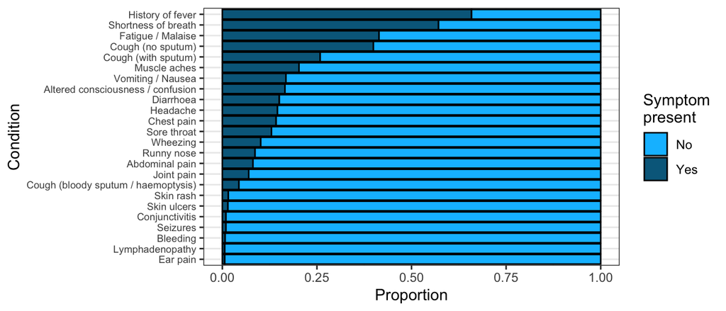

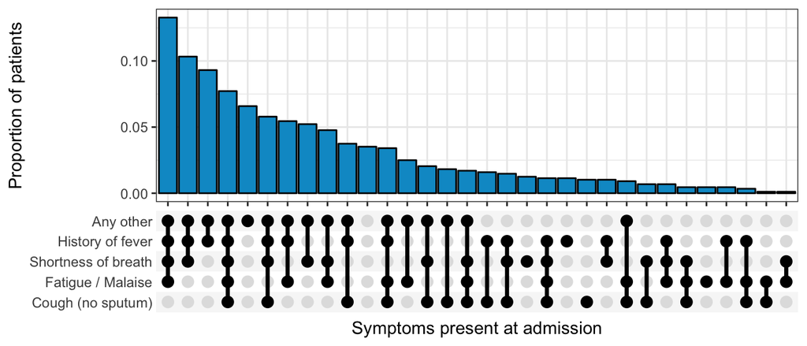

**Figure 3**: Top: Frequency of comorbidities seen at admission amongst COVID-19 patients. Bottom: The distribution of combinations of the four most common comorbidities, amongst all patients for whom this data was recorded. Filled and empty circles below the x-axis indicate the presence or absence of each comorbidity. The “Any other” category contains all remaining comorbidities in the top plot, and any other comorbidities recorded as free text by clinical staff.

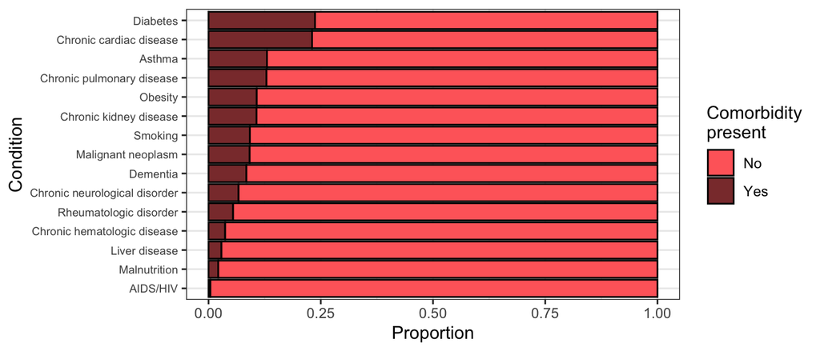

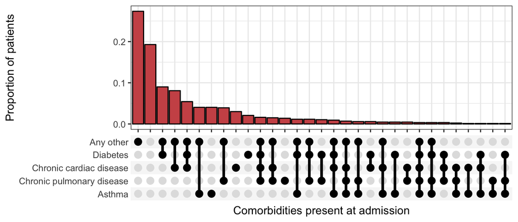

# 3 Hospital stays and outcomes

**Figure 4**: Distribution of length of hospital stay, according to sex. This only includes cases with reported outcomes. The coloured areas indicate the kernel probability density of the observed data and the box plots show the mean and interquartile range of the variable of interest.

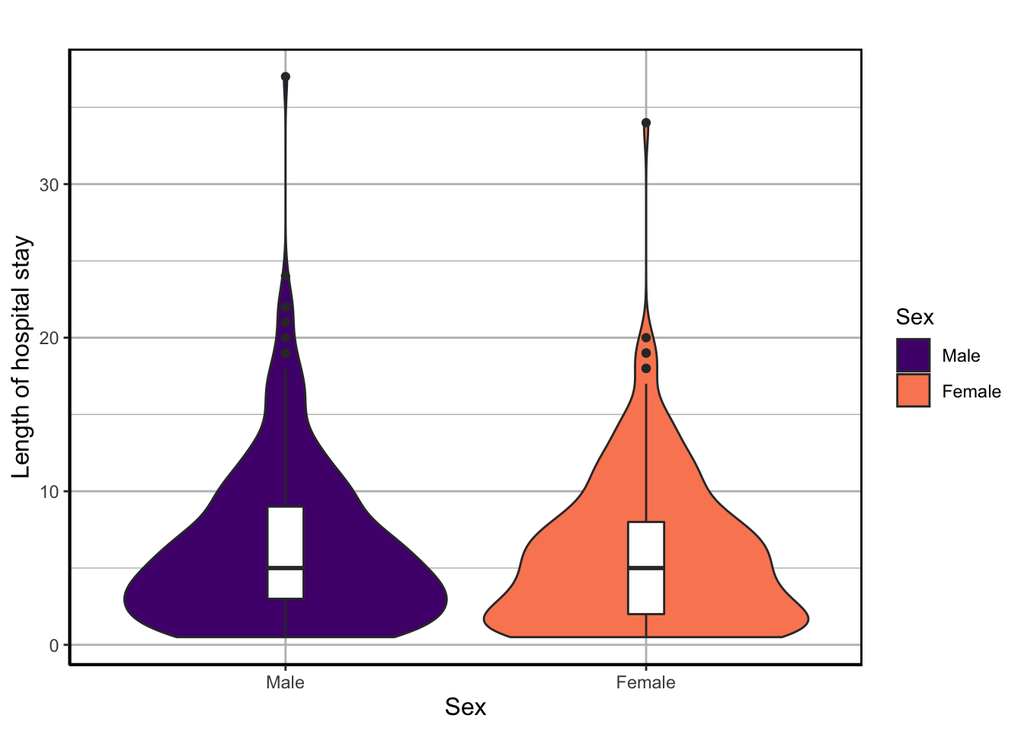

**Figure 5**: Distribution of length of hospital stay, according to patient age group. This only includes cases with reported outcomes. The coloured areas indicate the kernel probability density of the observed data and the box plots show the mean and interquartile range of the variable of interest.

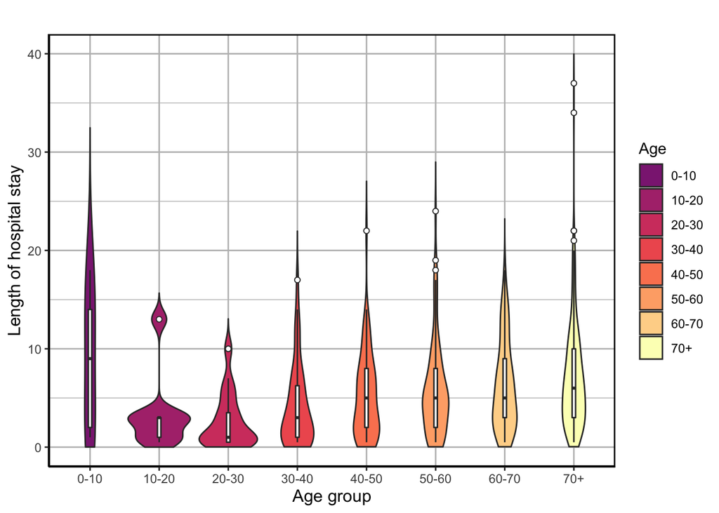

**Figure 6**: The distribution of patient status by number days after admission. Patients with “Unknown” status have left the site at the time of report but have unknown outcomes due to missing data. Patients with “Ongoing care” are still in site at the time of analysis. The black line marks the end of 14 days; due to the cut-off, only a small number of patients (those acquiring the infection in hospital) appear in the “ongoing care” category left of this line.

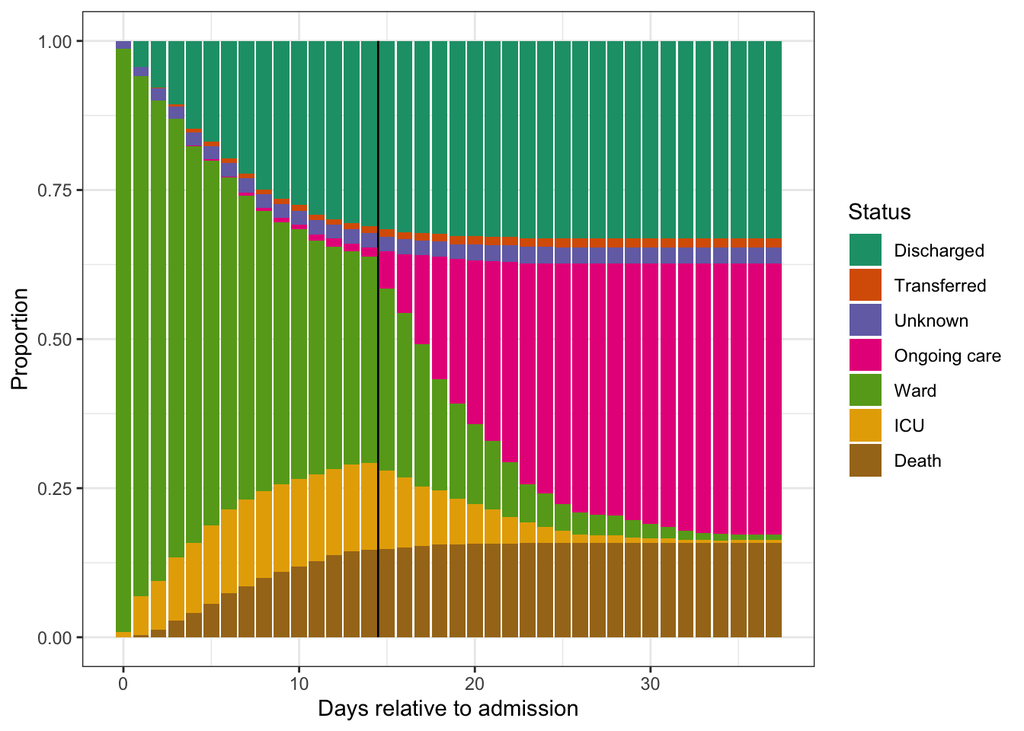

**Figure 7**: Patient numbers and outcomes by epidemiological week (of 2020) of admission (or, for patients infected in hospital, of symptom onset). The rightmost bar, marked with an asterisk, represents an incomplete week (due to the 14-day cutoff).

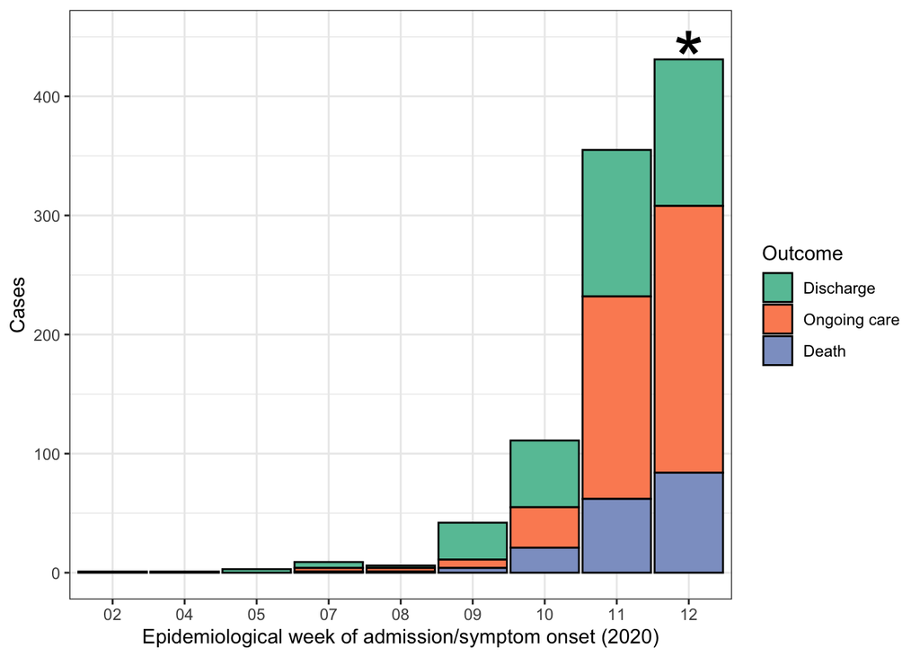

# 4 Treatment

**Figure 8**: Treatments used. This only includes patients where this information was recorded.

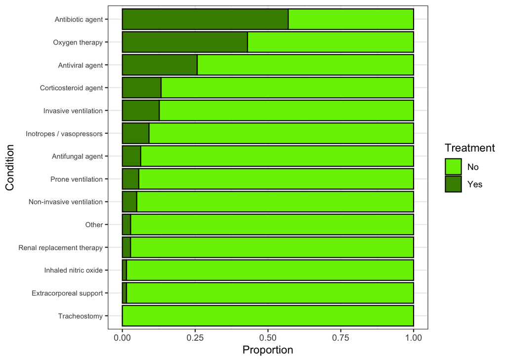

**Figure 9**: The distribution of combinations of antimicrobial treatments and steroids administered during hospital stay, across all patients with completed hospital stay and recorded treatment data. Filled and empty circles below the x-axis indicate treatments that were and were not administered.

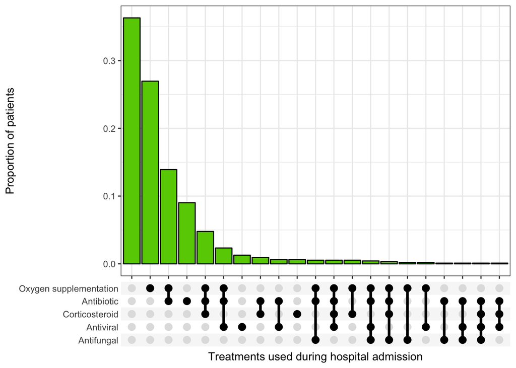

# 5 Intensive Care Unit Treatments

These figures include only the 251 patients who were admitted to an Intensive Care Unit.

**Figure 10**: Treatments used. This only includes patients where this information was recorded.

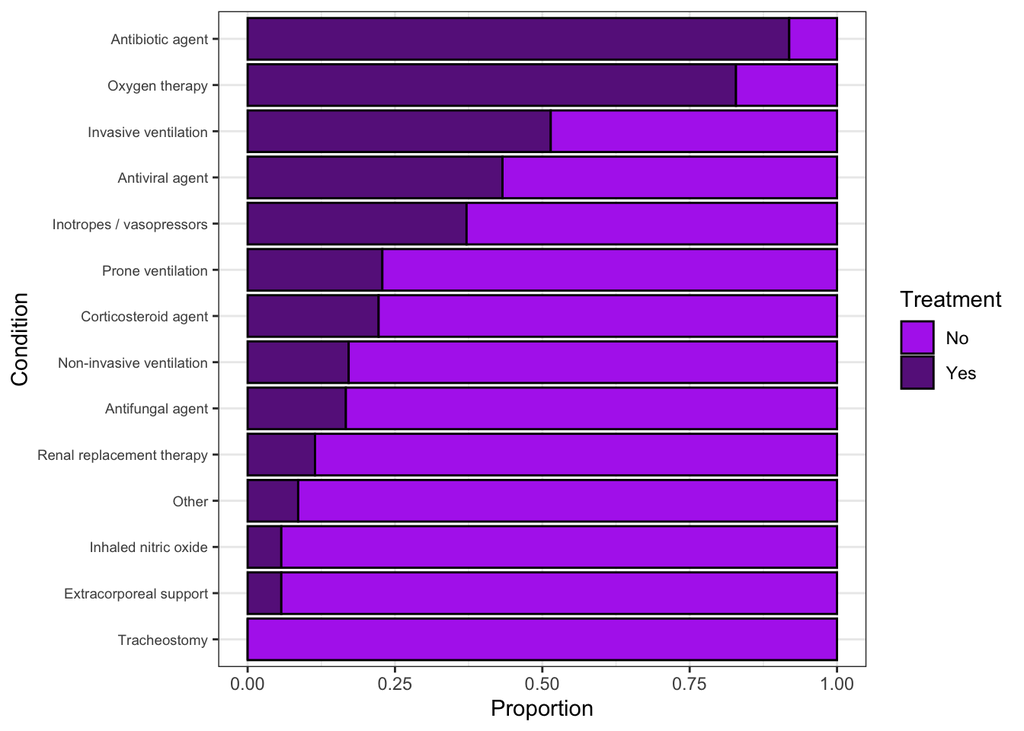

**Figure 11**: The distribution of combinations of treatments administered during hospital stay for patients who were admitted to an Intensive Care Unit. Filled and empty circles below the x-axis indicate treatments that were and were not administered.

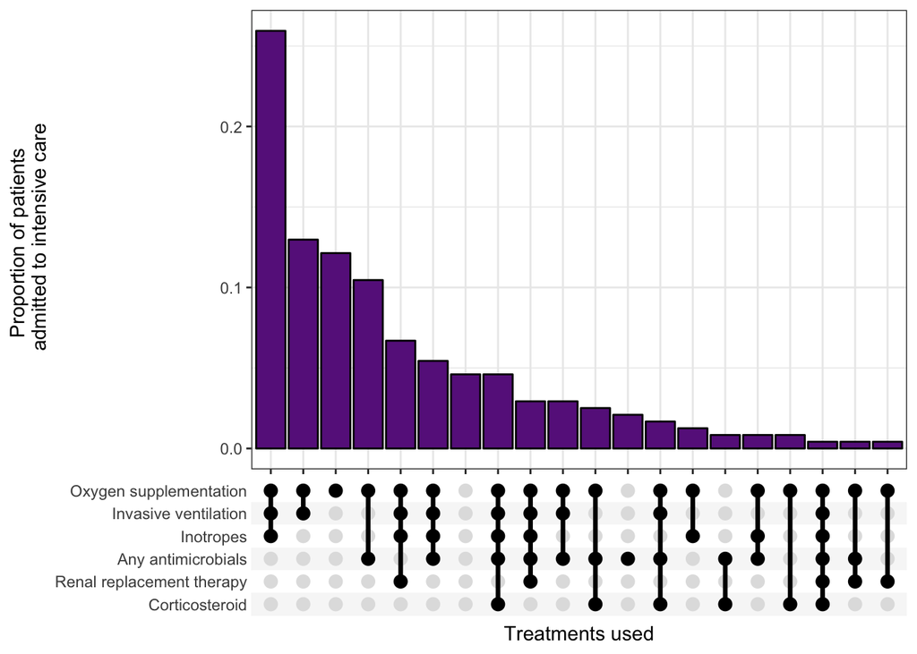

**Figure 12** Distribution of lengths of stay for patients who were admitted to an Intensive Care Unit: total length of stay for this group and length of stay within Intensive Care. This only includes cases with reported completed stays. The coloured areas indicate the kernel probability density of the observed data and the box plots show the mean and interquartile range of the variable of interest.

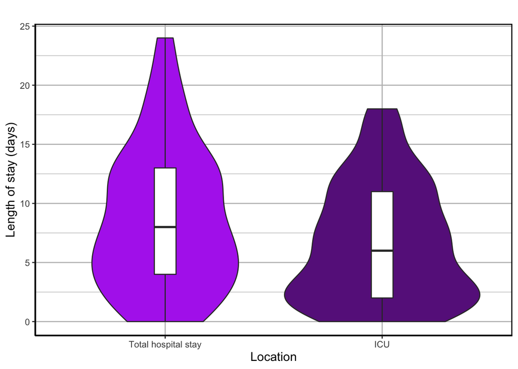

# 6 Statistical Analysis

**Figure 13**: Distribution of time from symptom onset to admission. The blue curve is the Gamma distribution fit to the data. The black dashed line indicates the position of the expected mean. Expected estimates, accounting for unobserved outcomes, are provided in the summary tables at the end of this report.

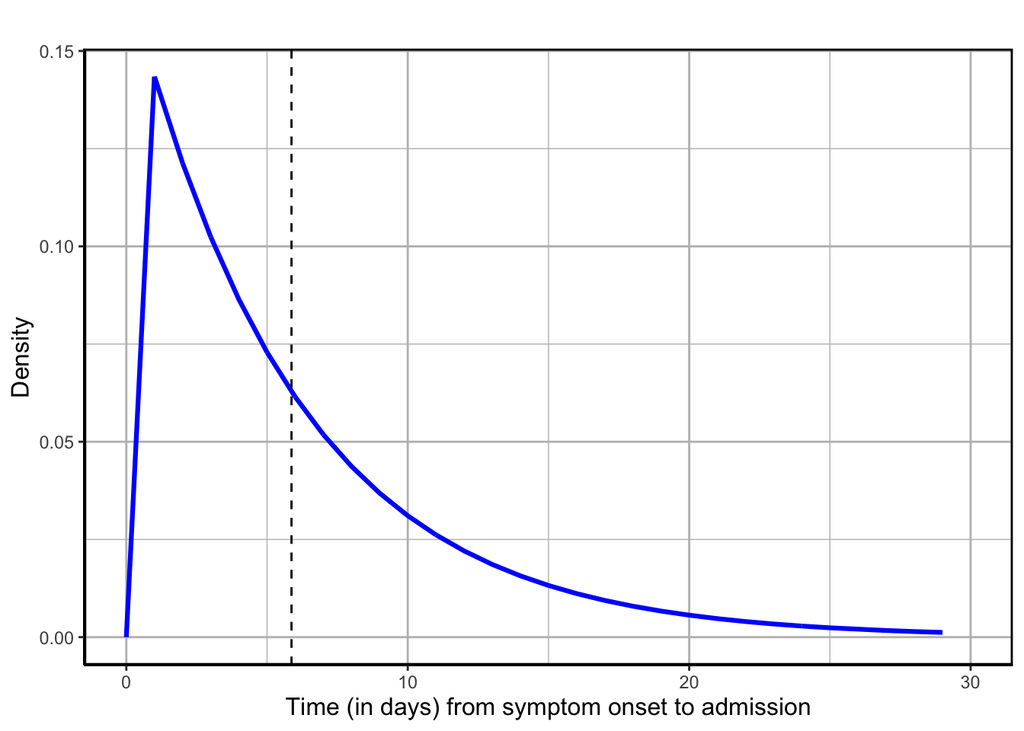

**Figure 14**: Distribution of time from admission to an outcome - either death or recovery (discharge). The blue curve is the Gamma distribution fit to the data. The black dashed line indicated the position of the expected mean.

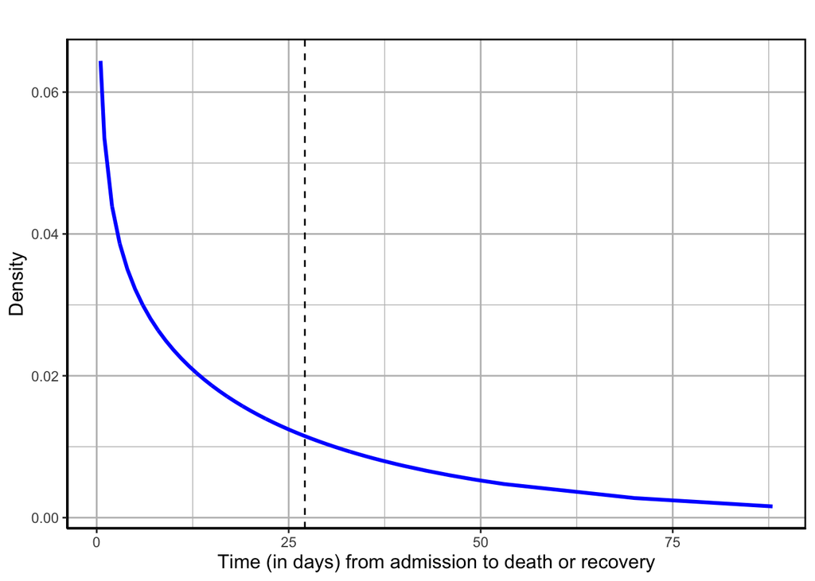

**Figure 15**: Nonparametric probabilities of death (red curve) and recovery (green curve) over time. The black line indicates the case fatality ratio (black). The method used here considers all cases, irrespective of whether an outcome has been observed. For a completed epidemic, the curves for death and recovery meet. Estimates were derived using a nonparametric Kaplan-Meier–based method proposed by Ghani *et al.* (2005).

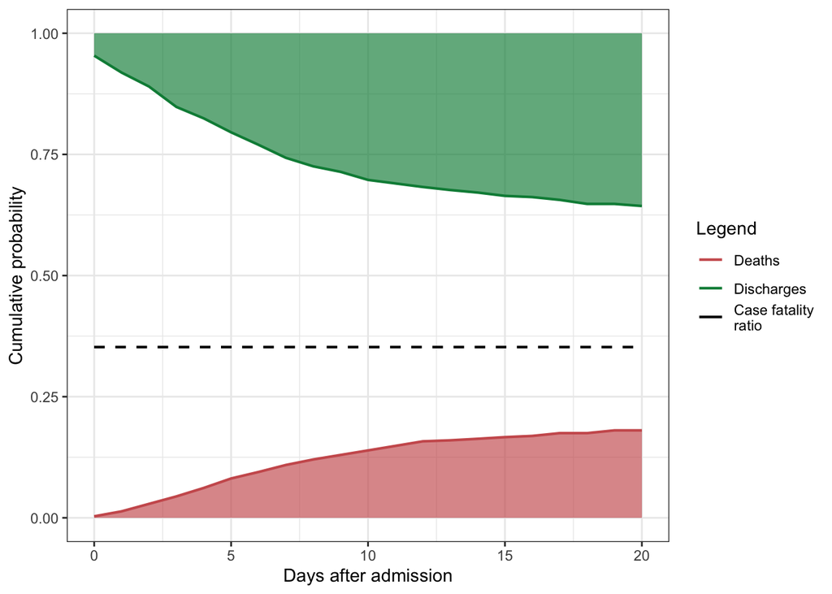

# 7 Country Comparisons

**Figure 16**: Number of sites per country.

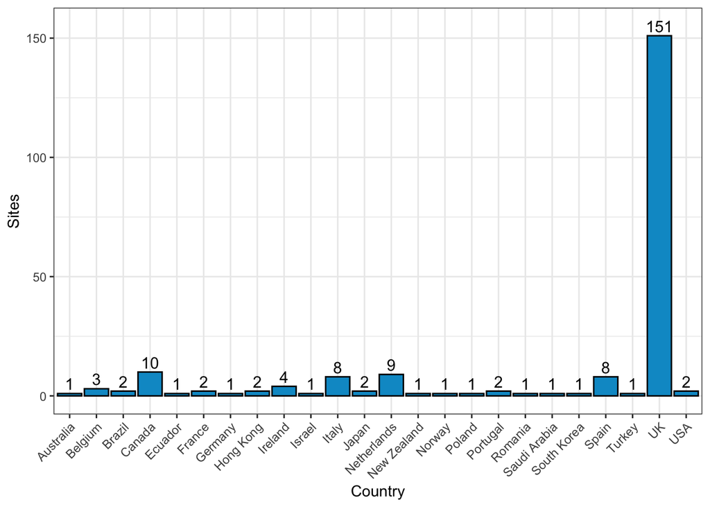

**Figure 17**: Distribution of patients by country and outcome

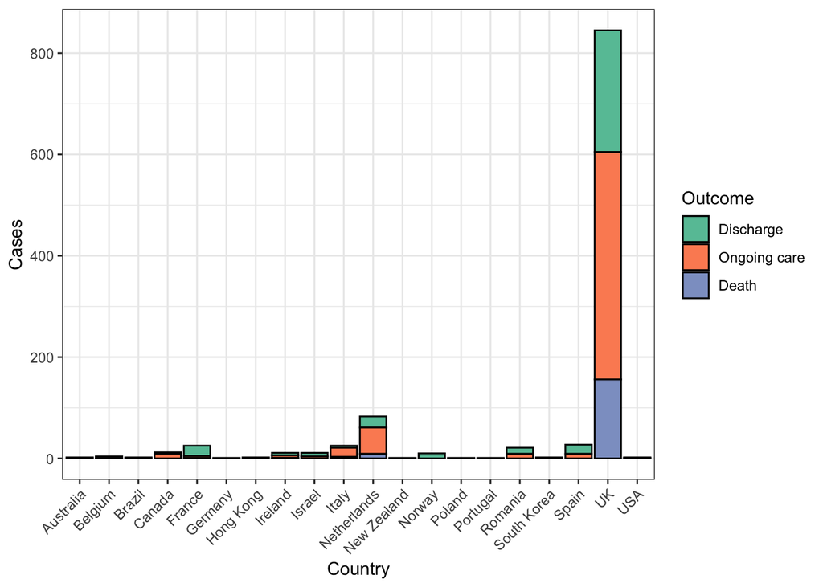

# 8 Recruitment

**Figure 18**: Cumulative recruitment of participants, separated by whether follow-up is ongoing or an outcome has been recorded. The first dashed black line indicates the exclusion date for this report: patients recruited after this date have not been included. The second black line is the exclusion date for next week’s report.

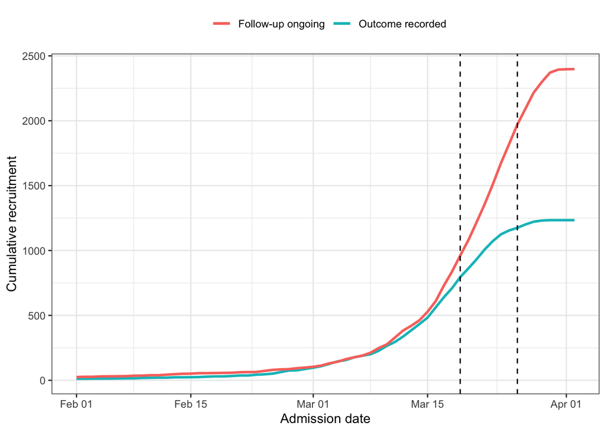

# 9 Background

In response to the emergence of novel coronavirus (COVID-19), ISARIC launched a portfolio of resources to accelerate outbreak research and response. All data collection tools are designed to address the most critical public health questions, have undergone extensive review by international clinical experts, and are free for all to use. Resources are available on the [ISARIC website](https://isaric.tghn.org/).

The [ISARIC-WHO COVID-19 Case Record Form (CRF)](https://media.tghn.org/medialibrary/2020/03/ISARIC_COVID-19_CRF_V1.3_24Feb2020.pdf) enables the collection of standardised clinical data to inform patient management and the public health response. These forms should be used to collect data on suspected or confirmed cases of COVID-19. The CRF is available in multiple languages and is now in use across dozens of countries and research consortia, who are contributing data to these reports.

To support the rapid implementation of standardised data collection and reporting, ISARIC hosts a data platform that includes an electronic data capture system, a secure repository and an analytic framework. Data are entered to a web-based REDCap data management system, securely stored, and used to inform regular reports as above. Data contributors are invited to input on the methods and contents of the reports, and are provided with the R code to execute analysis on their own data in the platform. For more information, visit the ISARIC website.

Following the launch of this these open resources, ISARIC received a massive response from the health and research communities. ISARIC supports researchers to retain control of the data and samples they collect. All decisions regarding data use are made by the institutions that enter the data. We keep our contributors informed of any plans and welcome their input to ensure that we are generating the best science and promoting the interests of your patients, your institutions and your public health authorities. Feedback and suggestions are welcome at ncov@isaric.org.

# 10 Methods

Patient details were submitted electronically by participating sites to the ISARIC database. Relevant background and presenting symptoms were recorded on the day of study recruitment. Daily follow-up was then completed until recovery or death. A final form was completed with details of treatments received and outcomes. All categories that represent fewer than five individuals have been suppressed to avoid the potential for identification of participants.

Graphs have been used to represent the age distribution of patience by sex and status (dead, recovered & still in hospital), the prevalence of individual symptoms - and combinations of them - on admission, the prevalence of individual comorbidities - and combinations of them - on admission, the length of hospital stay by sex and age group and the distribution of patient statuses by time since admission. In addition, the number of cases recruited by country and site, as well as the case count by status, has been represented.

Using a non-parametric Kaplan-Meier-based method (Ghani *et al.*, 2005), the case- fatality ratio (CFR) was estimated, as well as probabilities for death and recovery. This method estimates the CFR with the formula $a/(a+b)$, where $a$ and $b$ are the values of the cumulative incidence function for deaths and recoveries respectively, estimated at the last observed time point. In a competing risk context (i.e. where there are multiple endpoints), the cumulative incidence function for an endpoint is equal to the product of the hazard function for that endpoint and the survival function assuming a composite endpoint. It is worth noting that this method assumes that future deaths and recoveries will occur with the same relative probabilities as have been observed so far. Binomial confidence intervals for the CFR were obtained by a normal approximation (See Ghani *et al.*, (2005)).

A survival analysis was performed to test whether significant differences exist in the length of hospital stay by sex.

To obtain estimates for the distributions of time from symptom onset to hospital admission and the time from admission to outcome (death or recovery), Gamma distributions were fitted to the observed data, accounting for unobserved outcomes. Parameters were estimated by a maximum likelihood procedure and confidence intervals for the means and variances were obtained by bootstrap.

All analysis were performed using the R statistical software (R Core Team, 2019).

# 11 Caveats

Patient data are collected and uploaded from start of admission, however a complete patient data set is not available until the episode of care is complete. This causes a predictable lag in available data influenced by the duration of admission which is greatest for the sickest patients, and accentuated during the up-phase of the outbreak.

# 12 Summary Tables

**Table 1:** Patient Characteristics

| Description | Value |
| --- | --- |
| Size of cohort | 1123 |
| **By sex** |  |
| Male | 621 |
| Female | 413 |
| Unknown | 89 |
| **By Status** |  |
| Dead | 173 |
| Recovered (discharged alive) | 346 |
| Still in hospital | 571 |
| **By age group** |  |
| 0-10 | 8 |
| 10-20 | 11 |
| 20-30 | 42 |
| 30-40 | 82 |
| 40-50 | 105 |
| 50-60 | 165 |
| 60-70 | 162 |
| 70+ | 447 |
| Unknown | 101 |

**Table 2:** Prevalence of Symptoms, Comorbidities and Treatments

| **Symptoms** | **Present** | **Absent** | **Unknown** |
| --- | --- | --- | --- |
| Abdominal pain | 77 | 694 | 352 |
| Bleeding | 7 | 758 | 358 |
| Chest pain | 135 | 631 | 357 |
| Confusion | 157 | 625 | 341 |
| Conjuctivitis | 9 | 669 | 445 |
| Cough | 520 | 225 | 378 |
| Diarrhoea | 143 | 636 | 344 |
| Ear pain | 6 | 630 | 487 |
| Fatigue | 393 | 339 | 391 |
| Fever | 631 | 255 | 237 |
| Headache | 138 | 533 | 452 |
| Joint pain | 66 | 576 | 481 |
| Lymph | 6 | 653 | 464 |
| Myalgia | 192 | 483 | 448 |
| Rash | 15 | 671 | 437 |
| Runny nose | 82 | 583 | 458 |
| Seizures | 9 | 748 | 366 |
| Shortness of breath | 548 | 411 | 164 |
| **Comorbidities** |  |  |  |
| AIDS/HIV | 4 | 894 | 225 |
| Asthma | 127 | 788 | 208 |
| Chronic cardiac disease | 225 | 695 | 203 |
| Chronic haematologic disease | 36 | 872 | 215 |
| Chronic neurological disorder | 65 | 841 | 217 |
| Chronic pulmonary disease | 126 | 792 | 205 |
| Dementia | 82 | 830 | 211 |
| Diabetes | 231 | 742 | 150 |
| Liver disease | 28 | 881 | 214 |
| Malignant neoplasm | 89 | 819 | 215 |
| Malnutrition | 21 | 851 | 251 |
| Obesity | 104 | 758 | 261 |
| Chronic kidney disease | 104 | 810 | 209 |
| Rheumatologic disorder | 53 | 849 | 221 |
| Smoking | 68 | 473 | 582 |
| Other risk factors | 286 | 558 | 279 |
| **Treatment** |  |  |  |
| Antibiotic agent | 82 | 62 | 979 |
| Antifungal agent | 9 | 134 | 980 |
| Antiviral agent | 37 | 107 | 979 |
| Corticosteroid agent | 19 | 124 | 980 |
| Extracorporeal support | 2 | 139 | 982 |
| Inhaled nitric oxide | 2 | 139 | 982 |
| Inotropes / vasopressors | 13 | 128 | 982 |
| Invasive ventilation | 154 | 786 | 183 |
| Non-invasive ventilation | 107 | 825 | 191 |
| Oxygen therapy | 444 | 679 | 0 |
| Prone ventilation | 8 | 133 | 982 |
| Renal replacement therapy | 4 | 137 | 982 |
| Tracheostomy inserted | 0 | 141 | 982 |
| Other | 4 | 135 | 984 |
| Extracorporeal membrane oxygenation (ECMO) | 10 | 679 | 0 |

**Table 3:** Key time variables.

Unlike the observed mean, the estimation process of the **expected mean** accounts for all cases, irrespective of whether an outcome has been observed. The expected mean is ‘NA’ for those variables for which parameter estimation could not be performed, due to the high proportion of unobserved end dates.

| Time (in days) | Observed mean | Observed SD | Observed median | Expected mean (95% CI) |
| --- | --- | --- | --- | --- |
| Length of hospital stay | 6.5 | 5.7 | 5 | 27.1 (25.5, 29.3) |
| Symptom onset to admission | 6.9 | 5.9 | 4 | 5.9 (5.5, 6.2) |
| Admission to ICU entry | 2.9 | 4.5 | 1 | 2.9 (2.7, 3.1) |
| Duration of ICU | 6.9 | 4.7 | 6 | NA |
| Admission to IMV | 2.4 | 3.3 | 1 | 2.4 (2.2, 2.5) |
| Duration of IMV | 8.4 | 4.9 | 9 | NA |
| Admission to NIV | 4 | 7 | 1 | 4 (3.8, 4.4) |
| Duration of NIV | 1.3 | 1.6 | 0.5 | 59.5 (55.9, 69.2) |

# 13 ISARIC Team Members

- Kenneth Bailie
- Gail Carson
- Emmanuelle A. Dankwa
- Annemarie Docherty
- Christl A. Donnelly
- Christophe Fraser
- Matthew Hall
- Hayley Hardwick
- Ewen Harrison
- Karl Holden
- Peter Horby
- Kalynn Kennon
- James Lee
- Laura Merson
- Sarah Moore
- Piero Olliaro
- Daniel Plotkin
- Mark Pritchard
- Clark Russell
- Calum Semple
- Louise Sigfrid
- All those who contributed the data, which enabled this report.

# 14 References

1. A. C. Ghani, C. A. Donnelly, D. R. Cox, J. T. Griffin, C. Fraser, T. H. Lam, L. M. Ho, W. S. Chan, R. M. Anderson, A. J. Hedley, G. M. Leung (2005). Methods for Estimating the Case Fatality Ratio for a Novel, Emerging Infectious Disease, *American Journal of Epidemiology*, 162(5), 479 - 486. [doi:10.1093/aje/kwi230](https://doi.org/10.1093/aje/kwi230).
2. R Core Team (2019). R: A language and environment for statistical computing. R Foundation for Statistical Computing, Vienna, Austria.